# hPHH_DRW

## Perform the DRW calculation on all the modules

All the unique combinations of sample_id and module_number will be filtered and later this will be looped over and the DRW functions will be applied

```r
# This chunk filters for all the unique combinations to loop over
module_samples <- expression_joined %>%
  filter(module_number != 0) %>%  # Exclude Module 0
  distinct(condition_id = sample_id, module_nr = module_number) #%>%
  #slice_tail(n = 398)  # Keep only the last x combinations, for testing the function
```

```r
handlers("txtprogressbar") # this is to show the progress of the long calculation
```

This is a very long calculation (~ 120 minutes on my local CPU (a relatively new Intel i5)), so will not be knitted. I tried to parallize it, but did not work. Probably due to not having enough RAM (8 GB) relative to the size of the data.

```r
with_progress({
  p <- progressor(steps = nrow(module_samples))

  drw_scores <- map_dfr(
    1:nrow(module_samples),
    function(i) {
      row <- module_samples[i, ]
      p()

        tryCatch({
        # Casting to the right data structures to be sure
        cond_id <- as.character(row$condition_id)
        mod_nr <- as.integer(row$module_nr)

        compute_drw_score(
          condition_id = cond_id,
          module_nr = mod_nr,
          expression_df = expression_cor_eg,
          TOM = TOM
        )

      }, error = function(e) {
        message("Error With ", row$condition_id, " × ", row$module_nr, ": ", e$message)
        return(NULL)
      })
    }
  )
})
```

```r
drw_scores          <- readRDS(file.path(data_dir, "drw_scores_PHH_r0.7.rds")) # reading the drw_scores
```

```r
print(head(drw_scores))
```

```
## # A tibble: 6 × 5
##   condition_id                        module_nr drw_score module_size drw_zscore
##   <chr>                                   <dbl>     <dbl>       <int>      <dbl>
## 1 TG_HPHH_SINGLE_24DINITROPHENOL_T2_…         5      0            495      0
## 2 TG_HPHH_SINGLE_24DINITROPHENOL_T3_…         5      0            495      0
## 3 TG_HPHH_SINGLE_24DINITROPHENOL_T2_…         5      0            495      0
## 4 TG_HPHH_SINGLE_24DINITROPHENOL_T3_…         5      0            495      0
## 5 TG_HPHH_SINGLE_24DINITROPHENOL_T2_…         5     -4.24         495     -0.191
## 6 TG_HPHH_SINGLE_24DINITROPHENOL_T3_…         5     -3.71         495     -0.167
```

```r
print(tail(drw_scores))
```

```
## # A tibble: 6 × 5
##   condition_id                     module_nr drw_score module_size drw_zscore
##   <chr>                                <dbl>     <dbl>       <int>      <dbl>
## 1 TG_HPHH_SINGLE_VENLAFAXINE_T3_C2       297         0           6          0
## 2 TG_HPHH_SINGLE_VENLAFAXINE_T3_C3       297         0           6          0
## 3 TG_HPHH_SINGLE_VITAMINA_T2_C2          297         0           6          0
## 4 TG_HPHH_SINGLE_VITAMINA_T3_C2          297         0           6          0
## 5 TG_HPHH_SINGLE_VITAMINA_T2_C3          297         0           6          0
## 6 TG_HPHH_SINGLE_VITAMINA_T3_C3          297         0           6          0
```

```r
sum(is.na(drw_scores$drw_score))
```

```
## [1] 0
```

No NA values

### Normalization

The DRW scores will be normalized for their module_size.

```r
#drw_scores <- drw_scores %>%
 # left_join(
    #GRR_vs_eg_score %>% select(sample_id, module_number, module_size),
   # by = c("condition_id" = "sample_id", "module_nr" = "module_number")
  #) %>%
  #mutate(
   # drw_zscore = drw_score / sqrt(module_size)
  #)
```

```r
sum(is.na(drw_scores$drw_zscore))
```

```
## [1] 0
```

No NA values

```r
#saveRDS(drw_scores, file = "drw_scores_PHH_r0.7.rds") # saving the drw_scores
```

# Evaluate the DRW scores on the PHH with the wGRR metric

The wDRW scores will be evaluated on the Gene Response Rate and Weighted Gene Response Rate (wGRR) metric, which is proposed as an evaluation metric for the topological activation of every unique combination of condition and module. The GRR and wGRR are presented as the following formulas:

$$\mathrm{GRR}(M_j) = \frac{ \displaystyle \sum_{i=1}^{n_j} \left( |\log_2
\mathrm{FC}_i| > 1.0 \,\wedge\, p_{\mathrm{adj},i} < 0.05 \right)}
{ n_j }$$

$$\mathrm{wGRR}(M_j) = \frac{ \displaystyle \sum_{i=1}^{n_j} \left(
|\log_2 \mathrm{FC}_i| > 1.0 \,\wedge\, p_{\mathrm{adj},i} < 0.05
\right) \cdot \mathrm{median(TOM)}_i }{ \sum_{i=1}^{n_j}
\mathrm{median(TOM)}_i }$$

The GRR represents the proportion of significantly expressed genes in a module (abs log2fc > 1.0 and padj < 0.05) and the wGRR weighs this proportion by the median(TOM) of a gene within a module.

## GRR and wGRR

```r
GRR_vs_DRW <- drw_scores %>%
  left_join(
    GRR_vs_eg_score %>% select(sample_id, module_number, GRR, wGRR),
    by = c("condition_id" = "sample_id", "module_nr" = "module_number")
  )
```

```r
sum(is.na(GRR_vs_DRW$wGRR))
```

```
## [1] 0
```

```r
min(GRR_vs_DRW$wGRR)
```

```
## [1] -1
```

```r
max(GRR_vs_DRW$wGRR)
```

```
## [1] 1
```

## Density plots of GRR, wGRR and DRW score

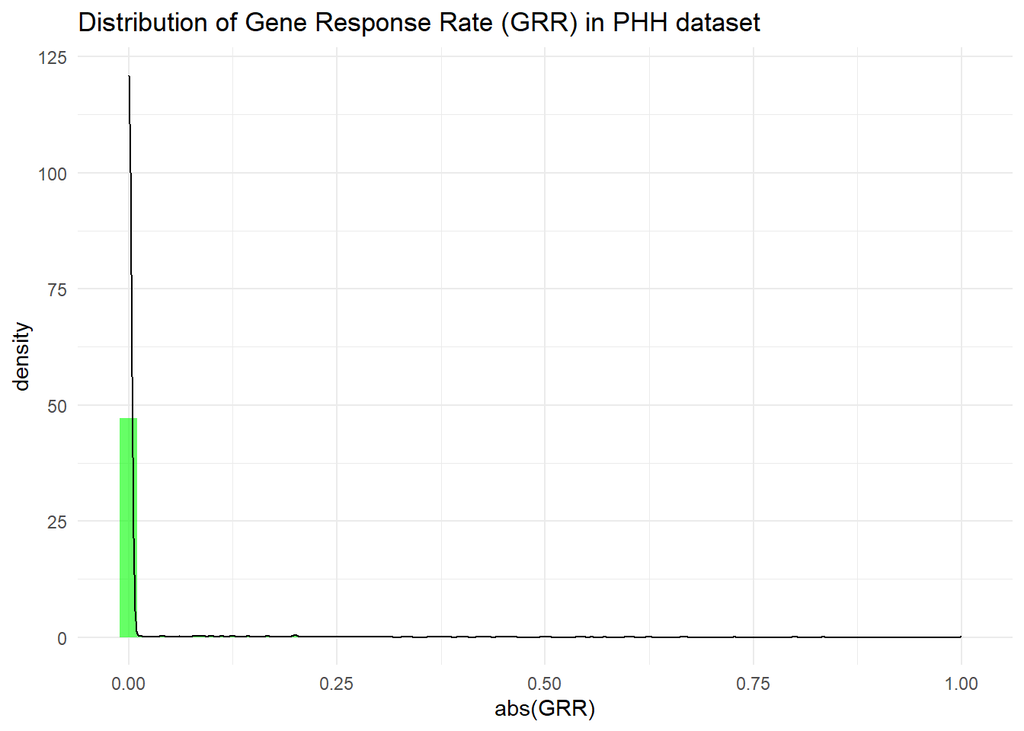

```r
ggplot(GRR_vs_DRW, aes(x = abs(GRR))) +
  geom_histogram(aes(y = ..density..), bins = 50, fill = "green", alpha = 0.6) +
  geom_density(color = "black") +
  theme_minimal() + labs(title = "Distribution of Gene Response Rate (GRR) in PHH dataset")
```

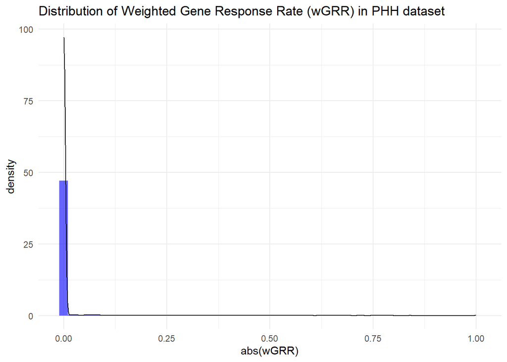

```r
ggplot(GRR_vs_DRW, aes(x = abs(wGRR))) +
  geom_histogram(aes(y = ..density..), bins = 50, fill = "blue", alpha = 0.6) +
  geom_density(color = "black") +
  theme_minimal() + labs(title = "Distribution of Weighted Gene Response Rate (wGRR) in PHH dataset")
```

Both abs(wGRR) and abs(GRR) log distributed

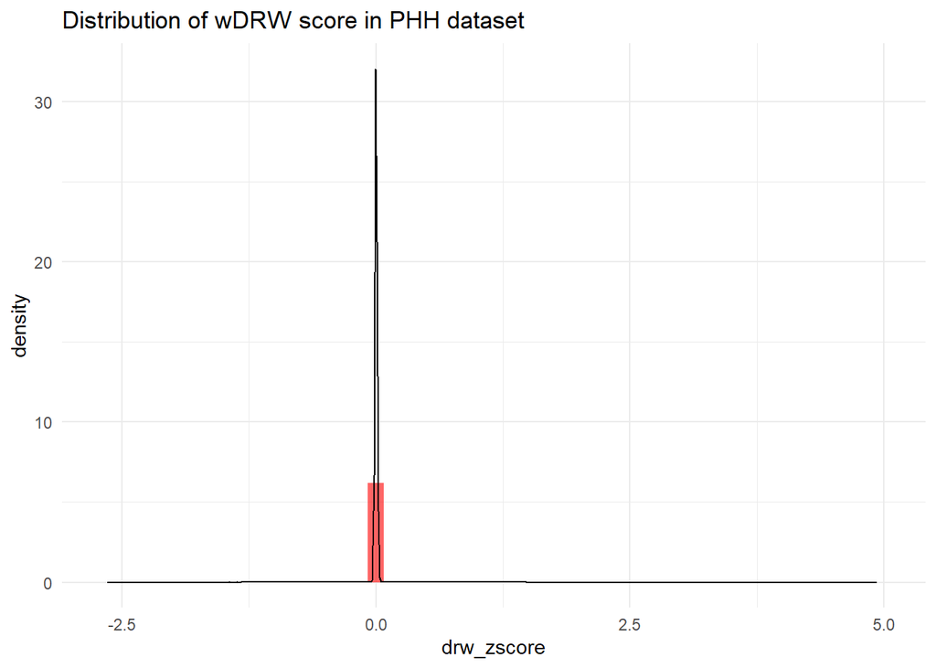

```r
ggplot(GRR_vs_DRW, aes(x = drw_zscore)) +
  geom_histogram(aes(y = ..density..), bins = 50, fill = "red", alpha = 0.6) +
  geom_density(color = "black") +
  theme_minimal() + labs(title = "Distribution of wDRW score in PHH dataset")
```

# Fitting wDRW vs GRR and wGRR using binomial GLMs

## Visualize GRR and wGRR vs DRW score with a linear fit

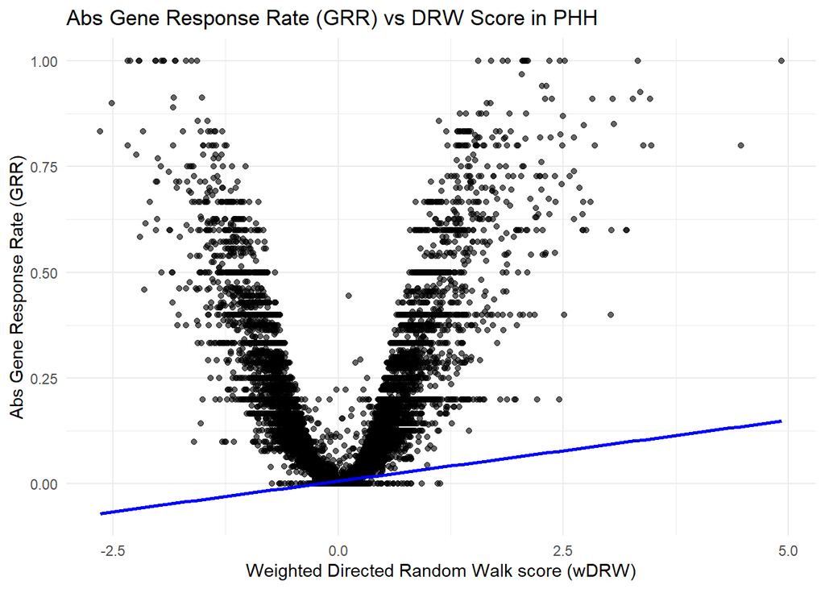

```r
ggplot(GRR_vs_DRW, aes(x = drw_zscore, y = abs(GRR))) +
  geom_point(alpha = 0.6) +
  geom_smooth(method = "lm", se = FALSE, color = "blue") +
  theme_minimal() +
  labs(
    title = "Abs Gene Response Rate (GRR) vs DRW Score in PHH",
    x = "Weighted Directed Random Walk score (wDRW)",
    y = "Abs Gene Response Rate (GRR)"
  )
```

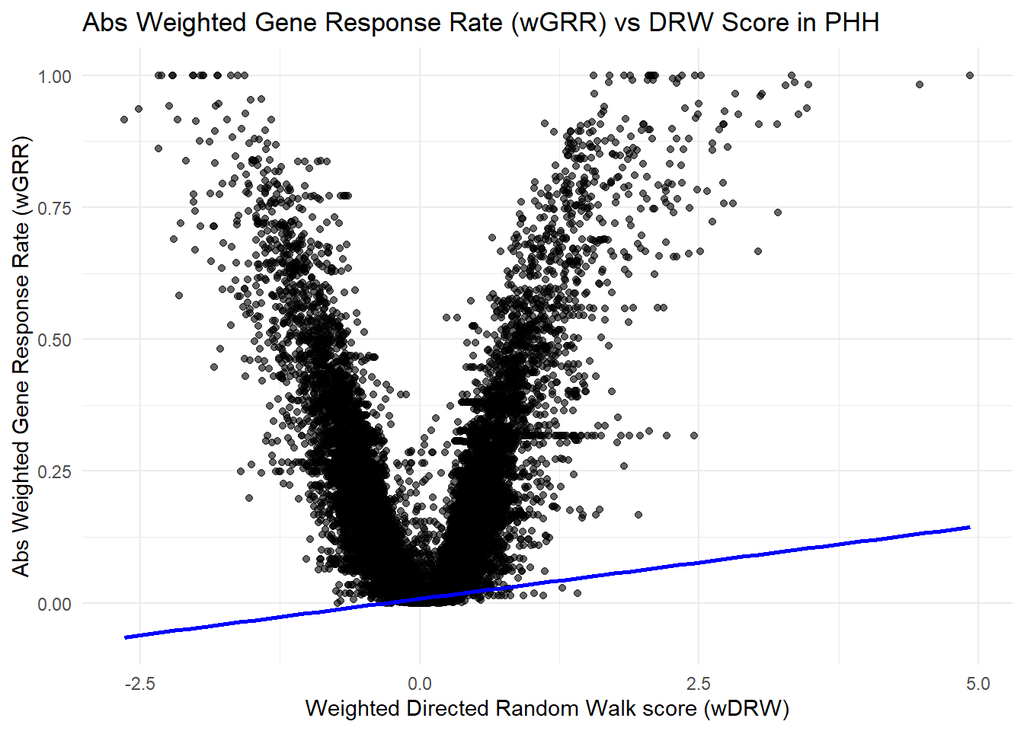

```r
ggplot(GRR_vs_DRW, aes(x = drw_zscore, y = abs(wGRR))) +
  geom_point(alpha = 0.6) +
  geom_smooth(method = "lm", se = FALSE, color = "blue") +
  theme_minimal() +
  labs(
    title = "Abs Weighted Gene Response Rate (wGRR) vs DRW Score in PHH",
    x = "Weighted Directed Random Walk score (wDRW)",
    y = "Abs Weighted Gene Response Rate (wGRR)"
  )
```

The linear fit does not fit the data well visually, so a binomial glm will be fitted and outliers will be calculated from this fit.

## Binomial Generalized Linear Model (GLM): GRR vs DRW

```r
glm_data <- GRR_vs_DRW %>%
  filter(!is.na(GRR), !is.na(drw_zscore)) # This filtering was performed as the function was first tested on a subset, but the filtering is irrelevant for the whole dataset as there are no NAs
```

```r
glm_fit <- glm(
  abs(GRR) ~ abs(drw_zscore), # absolute because of binomial
  data = glm_data,
  family = quasibinomial(link = "logit") # quasibinomial as the wGRR is a proportion multiplied by a continuous variable, the cor_eg.
)
```

```r
# Make predictions and residuals
glm_predictions <- predict(glm_fit, type = "response")
glm_dev_resid <- residuals(glm_fit, type = "deviance")

# Combine into a new dataframe
GRR_glm_fit_df <- glm_data %>%
  mutate(
    fitted_GRR = glm_predictions,
    GRR_resid = abs(GRR) - fitted_GRR,
    dev_resid = glm_dev_resid
  )
```

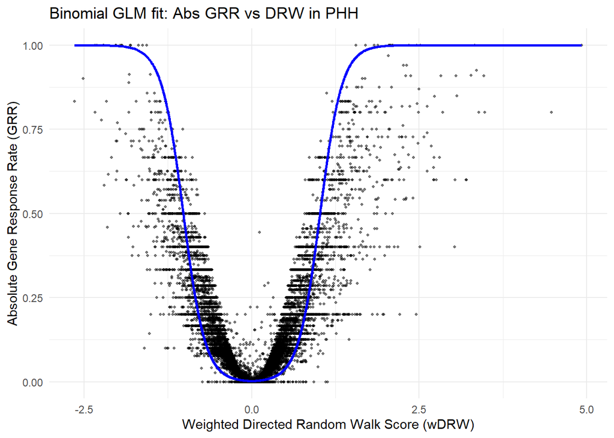

```r
ggplot(GRR_glm_fit_df, aes(x = drw_zscore, y = abs(GRR))) +
  geom_point(alpha = 0.5, size = 0.8) +
  geom_line(aes(y = fitted_GRR), color = "blue", size = 1) +
  theme_minimal() +
  labs(
    title = "Binomial GLM fit: Abs GRR vs DRW in PHH",
    x = "Weighted Directed Random Walk Score (wDRW)",
    y = "Absolute Gene Response Rate (GRR)"
  )
```

Visually, there are less outlying points using the DRW score than using the abs Eigengene score.

```r
summary(glm_fit)
```

```
##
## Call:
## glm(formula = abs(GRR) ~ abs(drw_zscore), family = quasibinomial(link = "logit"),
##     data = glm_data)
##
## Coefficients:
##                 Estimate Std. Error t value Pr(>|t|)
## (Intercept)      -6.2620     0.4695 -13.338  < 2e-16 ***
## abs(drw_zscore)   6.1342     0.7763   7.901 2.77e-15 ***
## ---
## Signif. codes:  0 '***' 0.001 '**' 0.01 '*' 0.05 '.' 0.1 ' ' 1
##
## (Dispersion parameter for quasibinomial family taken to be 171.0741)
##
##     Null deviance: 18396.9  on 374517  degrees of freedom
## Residual deviance:  4702.8  on 374516  degrees of freedom
## AIC: NA
##
## Number of Fisher Scoring iterations: 9
```

### significant outliers

For each module and sample, we compare the observed number of significant genes to the expected number based on the binomial GLM, and calculate a two-sided z-score and p-value using the binomial standard error. By doing this, the significant outlying modules from the glm fit are identified.

```r
GRR_glm_fit_df <- GRR_glm_fit_df %>%
  mutate(
    se_fit = sqrt(fitted_GRR * (1 - fitted_GRR) / module_size),
    z_score = GRR_resid / se_fit,
    p_value = 2 * pnorm(-abs(z_score))  # two-sided test
  )
```

```r
GRR_glm_fit_df <- GRR_glm_fit_df %>%
  mutate(
    outlier = p_value < 0.05,
    outlier_direction = case_when(
      outlier & z_score > 0 ~ "Above fit",
      outlier & z_score < 0 ~ "Below fit",
      TRUE ~ "Not significant"
    )
  )
```

```r
GRR_glm_fit_df <- GRR_glm_fit_df %>%
  mutate(module = paste0("hPHH_", module_nr)) %>%
  left_join(module_annotation, by = "module")
```

```r
sum(GRR_glm_fit_df$outlier, na.rm = TRUE)
```

```
## [1] 6625
```

There are 6625 outliers found. This is less than the eg score outliers for GRR

```r
total_modules_all <- GRR_glm_fit_df %>%
  filter(module_nr != 0) %>%
  summarise(n = n_distinct(module_nr)) %>%
  pull(n) # for normalization
```

```r
total_conditions_all <- GRR_glm_fit_df %>%
  filter(module_nr != 0) %>%
  summarise(n = n_distinct(condition_id)) %>%
  pull(n) # for normalization
```

```r
# Make a summarizing df for comparing with other datasets and scoring algorithms
outlier_density <- GRR_glm_fit_df %>%
  filter(outlier, module_nr != 0) %>%
  group_by(outlier_direction) %>%
  summarise(
    total_outliers = n(),
    .groups = "drop"
  ) %>%
  bind_rows(
    tibble(
      outlier_direction = "Total",
      total_outliers = sum(.$total_outliers)
    )
  ) %>%
  mutate(
    total_modules = total_modules_all,
    total_conditions = total_conditions_all,
    density = total_outliers / (total_modules * total_conditions)
  )
```

```r
print(outlier_density)
```

```
## # A tibble: 3 × 5
##   outlier_direction total_outliers total_modules total_conditions density
##   <chr>                      <int>         <int>            <int>   <dbl>
## 1 Above fit                   5892           398              941 0.0157
## 2 Below fit                    733           398              941 0.00196
## 3 Total                       6625           398              941 0.0177
```

Above shows the outlier density. n outliers / (n_conditions * n_modules

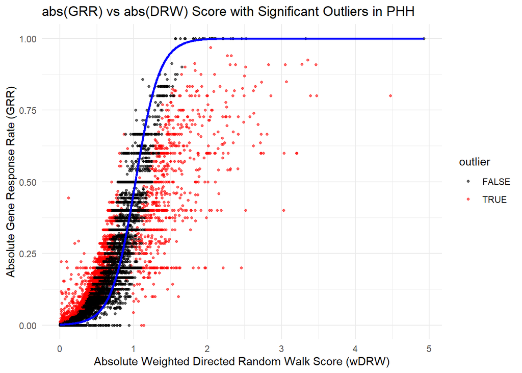

```r
ggplot(GRR_glm_fit_df, aes(x = abs(drw_zscore), y = abs(GRR))) +
  geom_point(aes(color = outlier), alpha = 0.6, size = 0.9) +
  geom_line(aes(y = fitted_GRR), color = "blue", size = 1) +
  scale_color_manual(values = c("black", "red")) +
  theme_minimal() +
  labs(
    title = "abs(GRR) vs abs(DRW) Score with Significant Outliers in PHH",
    x = "Absolute Weighted Directed Random Walk Score (wDRW)",
    y = "Absolute Gene Response Rate (GRR)"
  )
```

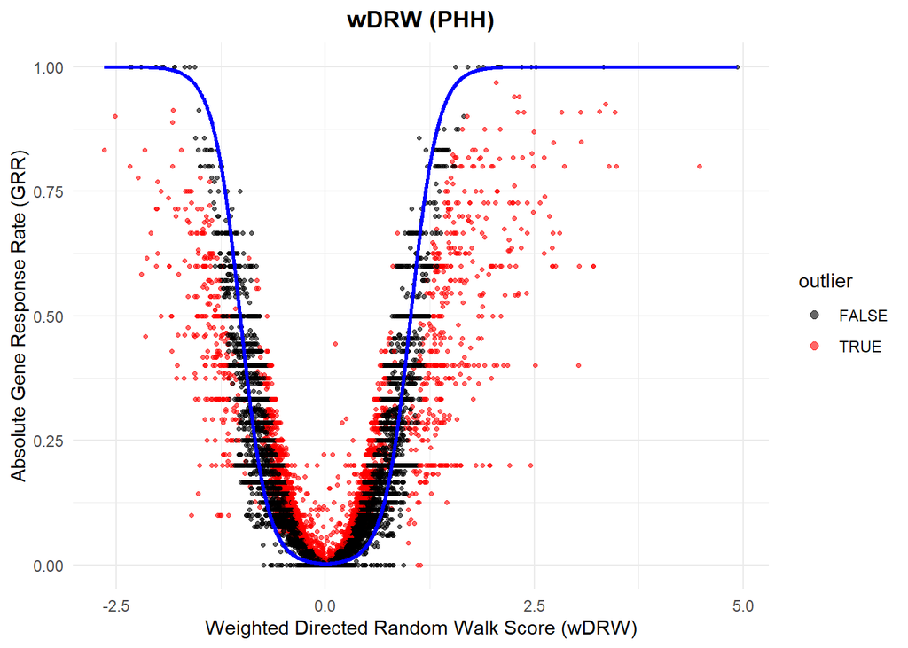

```r
ggplot(GRR_glm_fit_df, aes(x = drw_zscore, y = abs(GRR))) +
  geom_point(aes(color = outlier), alpha = 0.6, size = 0.9) +
  geom_line(aes(y = fitted_GRR), color = "blue", size = 1) +
  scale_color_manual(values = c("black", "red")) +
  theme_minimal() + theme(plot.title = element_text(hjust = 0.5, face = "bold")) +
  guides(color = guide_legend(override.aes = list(size = 2))) +
  labs(
    title = "wDRW (PHH)",
    x = "Weighted Directed Random Walk Score (wDRW)",
    y = "Absolute Gene Response Rate (GRR)"
  )
```

This fit shows, visually, less over and under quantification compared to the EG. especially the high EG scores (overquantification) with 0 gene responses are not present. Overall, this scoring shows less randomness than the eg scoring method on the proposed evaluation metric.

## Binomial Generalized Linear Model (GLM): wGRR vs DRW

```r
glm_data <- GRR_vs_DRW %>%
  filter(!is.na(wGRR), !is.na(drw_zscore), abs(wGRR)<=1) # This filtering was performed as the function was first tested on a subset, but the filtering is irrelevant for the whole dataset as there are no NAs. Also there was an error with wGRR because one value is above 1?
```

```r
glm_fit <- glm(
  abs(wGRR) ~ abs(drw_zscore),
  data = glm_data,
  family = quasibinomial(link = "logit") # quasibinomial as the wGRR is a proportion multiplied by a continuous variable, the cor_eg.
)
```

```r
# Make predictions and residuals
glm_predictions <- predict(glm_fit, type = "response")
glm_dev_resid <- residuals(glm_fit, type = "deviance")

# Combine into a new dataframe
GRR_glm_fit_df <- glm_data %>%
  mutate(
    fitted_wGRR = glm_predictions,
    wGRR_resid = abs(wGRR) - fitted_wGRR,
    dev_resid = glm_dev_resid
  )
```

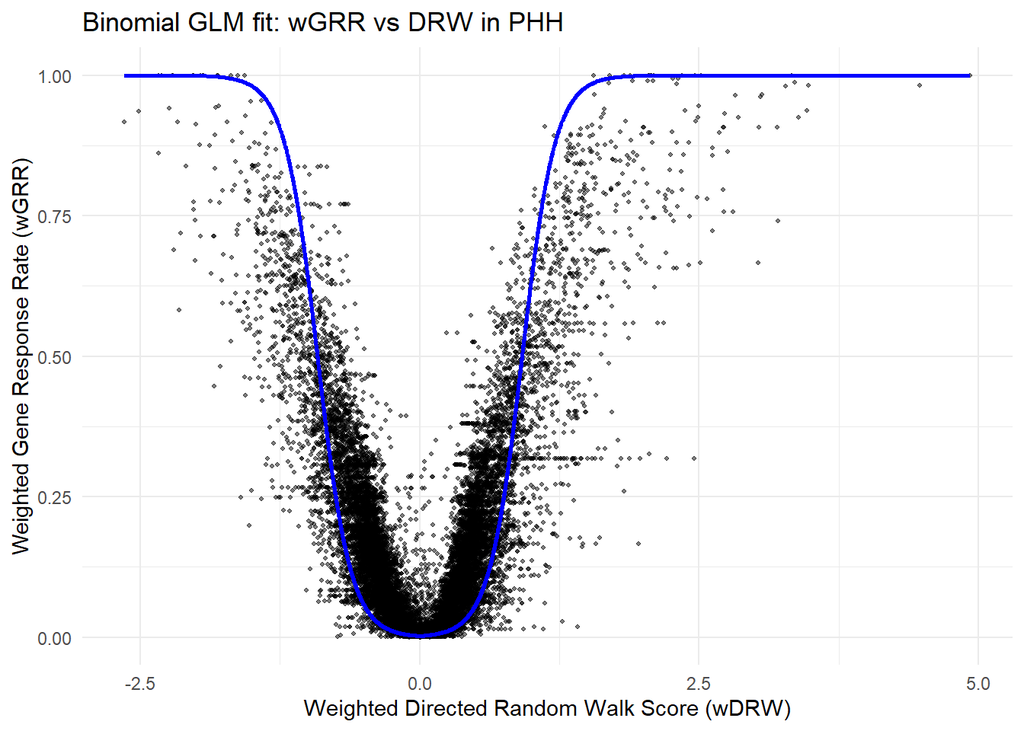

```r
ggplot(GRR_glm_fit_df, aes(x = drw_zscore, y = abs(wGRR))) +
  geom_point(alpha = 0.5, size = 0.8) +
  geom_line(aes(y = fitted_wGRR), color = "blue", size = 1) +
  theme_minimal() +
  labs(
    title = "Binomial GLM fit: wGRR vs DRW in PHH",
    x = "Weighted Directed Random Walk Score (wDRW)",
    y = "Weighted Gene Response Rate (wGRR)"
  )
```

Visually, there are less outlying points using the DRW score than using the abs Eigengene score.

```r
summary(glm_fit)
```

```
##
## Call:
## glm(formula = abs(wGRR) ~ abs(drw_zscore), family = quasibinomial(link = "logit"),
##     data = glm_data)
##
## Coefficients:
##                 Estimate Std. Error t value Pr(>|t|)
## (Intercept)      -6.1598     0.1682  -36.62   <2e-16 ***
## abs(drw_zscore)   6.7269     0.2983   22.55   <2e-16 ***
## ---
## Signif. codes:  0 '***' 0.001 '**' 0.01 '*' 0.05 '.' 0.1 ' ' 1
##
## (Dispersion parameter for quasibinomial family taken to be 24.26763)
##
##     Null deviance: 22796  on 374516  degrees of freedom
## Residual deviance:  5500  on 374515  degrees of freedom
## AIC: NA
##
## Number of Fisher Scoring iterations: 9
```

Fit is good

### significant outliers

For each module and sample, we compare the observed number of significant genes to the expected number based on the binomial GLM, and calculate a two-sided z-score and p-value using the binomial standard error. By doing this, the significant outlying modules from the glm fit are identified.

```r
GRR_glm_fit_df <- GRR_glm_fit_df %>%
  mutate(
    se_fit = sqrt(fitted_wGRR * (1 - fitted_wGRR) / module_size),
    z_score = wGRR_resid / se_fit,
    p_value = 2 * pnorm(-abs(z_score))  # two-sided test
  )
```

```r
GRR_glm_fit_df <- GRR_glm_fit_df %>%
  mutate(
    outlier = p_value < 0.05,
    outlier_direction = case_when(
      outlier & z_score > 0 ~ "Above fit",
      outlier & z_score < 0 ~ "Below fit",
      TRUE ~ "Not significant"
    )
  )
```

```r
GRR_glm_fit_df <- GRR_glm_fit_df %>%
  mutate(module = paste0("hPHH_", module_nr)) %>%
  left_join(module_annotation, by = "module")
```

```r
sum(GRR_glm_fit_df$outlier, na.rm = TRUE)
```

```
## [1] 6628
```

There are 6628 outliers found. This is less than the eg score.

```r
total_modules_all <- GRR_glm_fit_df %>%
  filter(module_nr != 0) %>%
  summarise(n = n_distinct(module_nr)) %>%
  pull(n) # for normalization
```

```r
total_conditions_all <- GRR_glm_fit_df %>%
  filter(module_nr != 0) %>%
  summarise(n = n_distinct(condition_id)) %>%
  pull(n) # for normalization
```

```r
# Make a summarizing df for comparing with other datasets and scoring algorithms
outlier_density <- GRR_glm_fit_df %>%
  filter(outlier, module_nr != 0) %>%
  group_by(outlier_direction) %>%
  summarise(
    total_outliers = n(),
    .groups = "drop"
  ) %>%
  bind_rows(
    tibble(
      outlier_direction = "Total",
      total_outliers = sum(.$total_outliers)
    )
  ) %>%
  mutate(
    total_modules = total_modules_all,
    total_conditions = total_conditions_all,
    density = total_outliers / (total_modules * total_conditions)
  )
```

```r
print(outlier_density)
```

```
## # A tibble: 3 × 5
##   outlier_direction total_outliers total_modules total_conditions density
##   <chr>                      <int>         <int>            <int>   <dbl>
## 1 Above fit                   5697           398              941 0.0152
## 2 Below fit                    931           398              941 0.00249
## 3 Total                       6628           398              941 0.0177
```

Outlier density

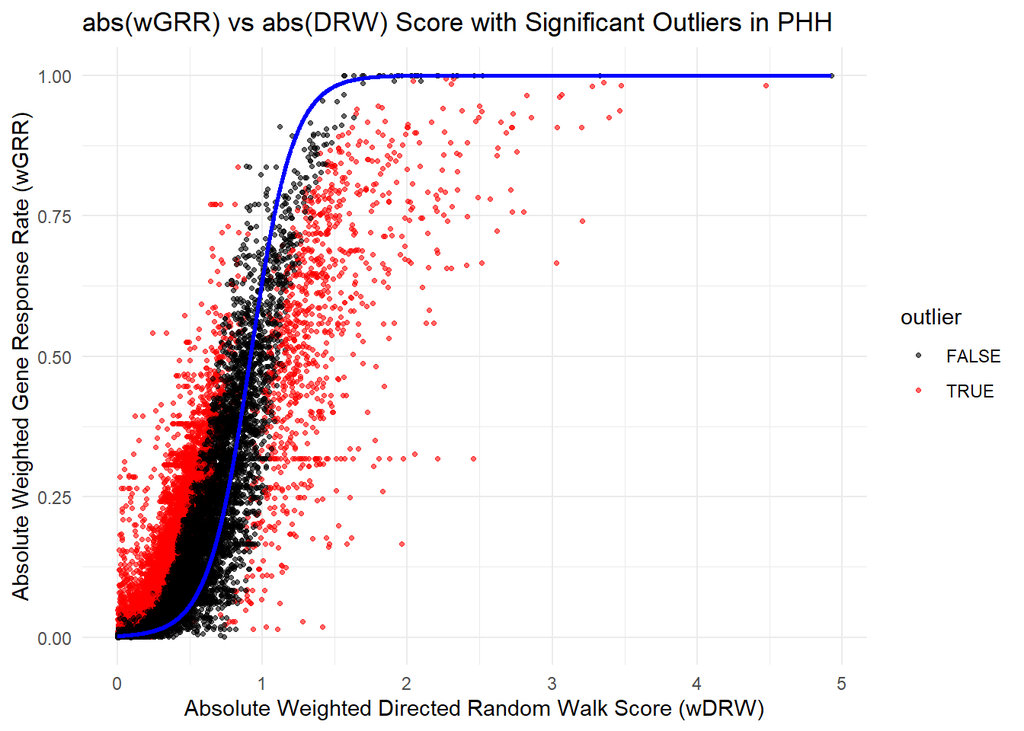

```r
ggplot(GRR_glm_fit_df, aes(x = abs(drw_zscore), y = abs(wGRR))) +
  geom_point(aes(color = outlier), alpha = 0.6, size = 0.9) +
  geom_line(aes(y = fitted_wGRR), color = "blue", size = 1) +
  scale_color_manual(values = c("black", "red")) +
  theme_minimal() +
  labs(
    title = "abs(wGRR) vs abs(DRW) Score with Significant Outliers in PHH",
    x = "Absolute Weighted Directed Random Walk Score (wDRW)",
    y = "Absolute Weighted Gene Response Rate (wGRR)"
  )
```

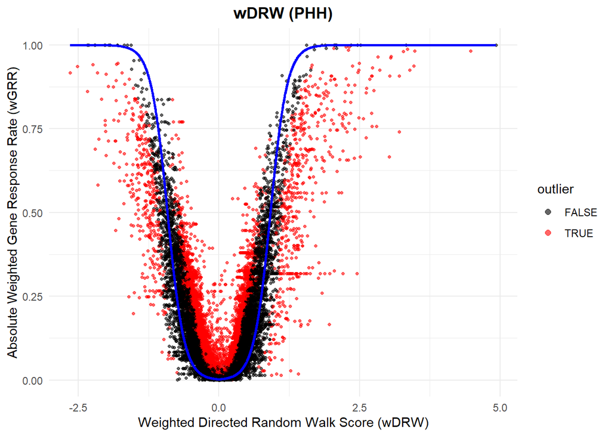

```r
ggplot(GRR_glm_fit_df, aes(x = drw_zscore, y = abs(wGRR))) +
  geom_point(aes(color = outlier), alpha = 0.6, size = 0.9) +
  geom_line(aes(y = fitted_wGRR), color = "blue", size = 1) +
  scale_color_manual(values = c("black", "red")) +
  theme_minimal() + theme(plot.title = element_text(hjust = 0.5, face = "bold")) +
  guides(color = guide_legend(override.aes = list(size = 2))) +
  labs(
    title = "wDRW (PHH)",
    x = "Weighted Directed Random Walk Score (wDRW)",
    y = "Absolute Weighted Gene Response Rate (wGRR)"
  )
```

## Modules and conditions with most significant outliers’

Based on the binomial GLM fit, we will now find the modules and conditions with the most significant outliers

```r
significant_outliers_filtered <- GRR_glm_fit_df %>%
  filter(outlier)
```

```r
outliers_per_module <- significant_outliers_filtered %>%
  count(module_nr, sort = TRUE)
```

```r
outliers_per_sample <- significant_outliers_filtered %>%
  count(condition_id, sort = TRUE)
```

```r
head(outliers_per_module, 10) # Top modules with outliers
```

```
## # A tibble: 10 × 2
##    module_nr     n
##        <dbl> <int>
##  1         1   215
##  2         2   178
##  3        11   168
##  4         4   155
##  5        44   153
##  6        15   146
##  7        16   129
##  8        12   100
##  9       358    93
## 10         3    90
```

```r
head(outliers_per_sample, 10) # Top cconditions with outliers
```

```
## # A tibble: 10 × 2
##    condition_id                                 n
##    <chr>                                    <int>
##  1 TG_HPHH_SINGLE_CYCLOHEXIMIDE_T3_C3         117
##  2 TG_HPHH_SINGLE_DOXORUBICIN_T3_C3            98
##  3 TG_HPHH_SINGLE_NMETHYLNNITROSOUREA_T3_C3    92
##  4 TG_HPHH_SINGLE_CYCLOHEXIMIDE_T3_C2          87
##  5 TG_HPHH_SINGLE_ETHIONINE_T3_C3              87
##  6 TG_HPHH_SINGLE_DOXORUBICIN_T3_C2            77
##  7 TG_HPHH_SINGLE_OMEPRAZOLE_T3_C3             75
##  8 TG_HPHH_SINGLE_PHENOBARBITAL_T3_C3          74
##  9 TG_HPHH_SINGLE_BROMOETHYLAMINE_T3_C3        73
## 10 TG_HPHH_SINGLE_ALLYLALCOHOL_T3_C3           72
```

### Outliers per module: total, below and above the fit with human annotation

Here, we will visualize the modules with the most outliers. Total, below and above the Binomial GLM fit.

#### Total outliers from the GLM fit

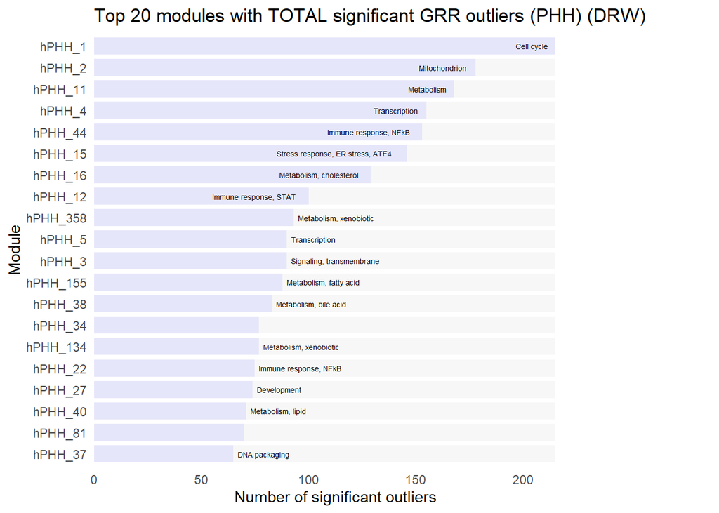

```r
threshold <- 100  # Same threshold

GRR_glm_fit_df %>%
  filter(outlier) %>%
  count(module, annotation, sort = TRUE) %>%
  slice_max(n, n = 20, with_ties = FALSE) %>%
  mutate(
    max_n = max(n),
    hjust_val = ifelse(n < threshold, 0, 1.1),
    label_pos = ifelse(n < threshold, n + 2, n - 2)
  ) %>%
  ggplot(aes(x = reorder(module, n))) +
  geom_col(aes(y = max_n), fill = "grey97", width = 0.8) +
  geom_col(aes(y = n), fill = "lavender", width = 0.8) +
  geom_text(
    aes(y = label_pos, label = annotation, hjust = hjust_val),
    size = 1.8, color = "black"
  ) +
  coord_flip(clip = "off") +
  scale_y_continuous(
    limits = c(0, max(GRR_glm_fit_df %>%
      filter(outlier) %>%
      count(module) %>%
      slice_max(n, n = 20, with_ties = FALSE) %>%
      pull(n)) + 10),
    expand = c(0, 0)
  ) +
  theme_minimal() +
  theme(
    plot.margin = margin(5.5, 100, 5.5, 5.5),
    panel.grid.major = element_blank(),
    panel.grid.minor = element_blank()
  ) +
  labs(
    title = "Top 20 modules with TOTAL significant GRR outliers (PHH) (DRW)",
    x = "Module",
    y = "Number of significant outliers"
  )
```

#### Outliers above the GLM fit

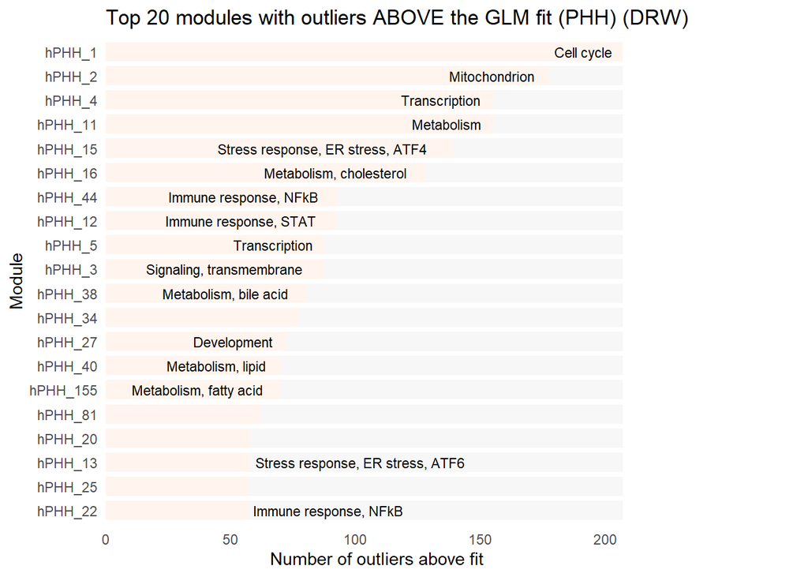

```r
threshold <- 70  # Threshold for switching annotation position

GRR_glm_fit_df %>%
  filter(outlier_direction == "Above fit") %>%
  count(module, annotation, sort = TRUE) %>%
  slice_max(n, n = 20, with_ties = FALSE) %>%
  mutate(
    max_n = max(n),
    hjust_val = ifelse(n < threshold, 0, 1.1),
    label_pos = ifelse(n < threshold, n + 2, n - 2)
  ) %>%
  ggplot(aes(x = reorder(module, n))) +
  geom_col(aes(y = max_n), fill = "grey97", width = 0.8) +
  geom_col(aes(y = n), fill = "seashell", width = 0.8) +
  geom_text(
    aes(y = label_pos, label = annotation, hjust = hjust_val),
    size = 3, color = "black"
  ) +
  coord_flip(clip = "off") +
  scale_y_continuous(
    limits = c(0, max(GRR_glm_fit_df %>%
      filter(outlier_direction == "Above fit") %>%
      count(module) %>%
      slice_max(n, n = 20, with_ties = FALSE) %>%
      pull(n)) + 10),
    expand = c(0, 0)
  ) +
  theme_minimal() +
  theme(
    plot.margin = margin(5.5, 100, 5.5, 5.5),
    panel.grid.major = element_blank(),
    panel.grid.minor = element_blank()
  ) +
  labs(
    title = "Top 20 modules with outliers ABOVE the GLM fit (PHH) (DRW)",
    x = "Module",
    y = "Number of outliers above fit"
  )
```

#### Outliers below the GLM fit

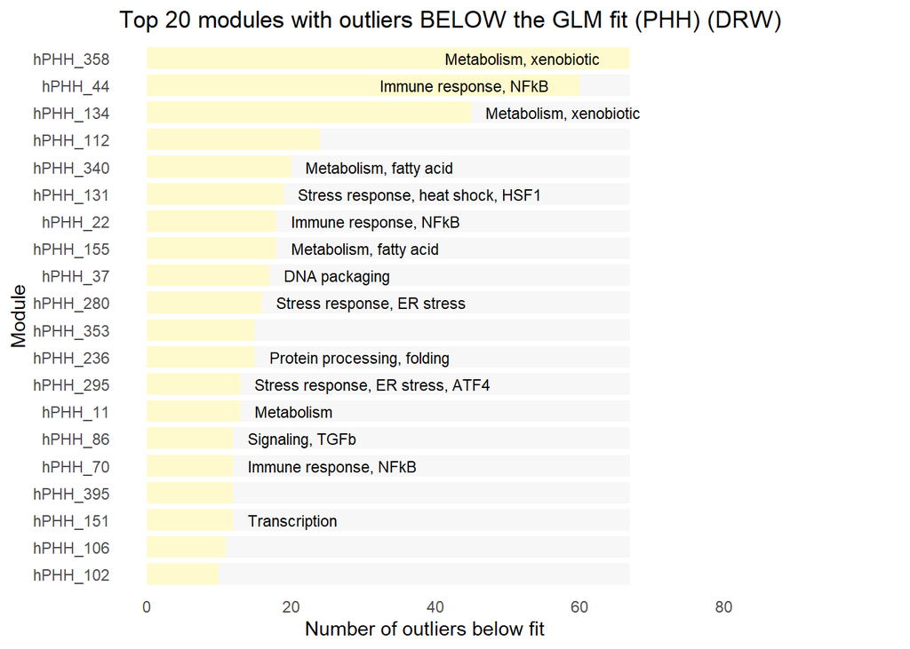

```r
threshold <- 50  # Threshold for annotation in plot

GRR_glm_fit_df %>%
  filter(outlier_direction == "Below fit") %>%
  count(module, annotation, sort = TRUE) %>%
  slice_max(n, n = 20, with_ties = FALSE) %>%
  mutate(
    max_n = max(n),
    hjust_val = ifelse(n < threshold, 0, 1.1),       # outside or inside
    label_pos = ifelse(n < threshold, n + 2, n - 2)  # offset label position
  ) %>%
  ggplot(aes(x = reorder(module, n))) +

  # Background bar
  geom_col(aes(y = max_n), fill = "grey97", width = 0.8) +

  # Foreground bar (actual value)
  geom_col(aes(y = n), fill = "lemonchiffon", width = 0.8) +

  # Smart annotation positioning
  geom_text(
    aes(y = label_pos, label = annotation, hjust = hjust_val),
    size = 3, color = "black"
  ) +

  coord_flip(clip = "off") +  # Flip axes for horizontal bars

  # Y-axis limits: no exessive white space
  scale_y_continuous(limits = c(0, max(GRR_glm_fit_df %>%
    filter(outlier_direction == "Below fit") %>%
    count(module) %>%
    slice_max(n, n = 20, with_ties = FALSE) %>%
    pull(n)) + 10)) +

  theme_minimal() +
  theme(
    plot.margin = margin(5.5, 100, 5.5, 5.5),
    panel.grid.major = element_blank(),
    panel.grid.minor = element_blank()
  ) +
  labs(
    title = "Top 20 modules with outliers BELOW the GLM fit (PHH) (DRW)",
    x = "Module",
    y = "Number of outliers below fit"
  )
```

### Outliers per sample: above, below and total.

Now, we will assess what conditions have the most outliers. Total, below and above the binomial GLM fit.

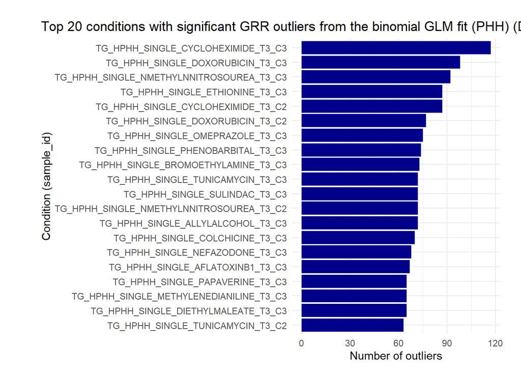

```r
outliers_per_sample %>%
  top_n(20, n) %>%
  ggplot(aes(x = reorder(condition_id, n), y = n)) +
  geom_col(fill = "darkblue") +
  coord_flip() +
  theme_minimal() +
  ggtitle("Top 20 conditions with significant GRR outliers from the binomial GLM fit (PHH) (DRW)") +
  theme(
    plot.title.position = "plot",
    plot.title = element_text(hjust = 0),
    plot.margin = margin(20, 20, 10, 40) # top, right, bottom, left
  ) +
  labs(
    x = "Condition (sample_id)",
    y = "Number of outliers"
  )
```

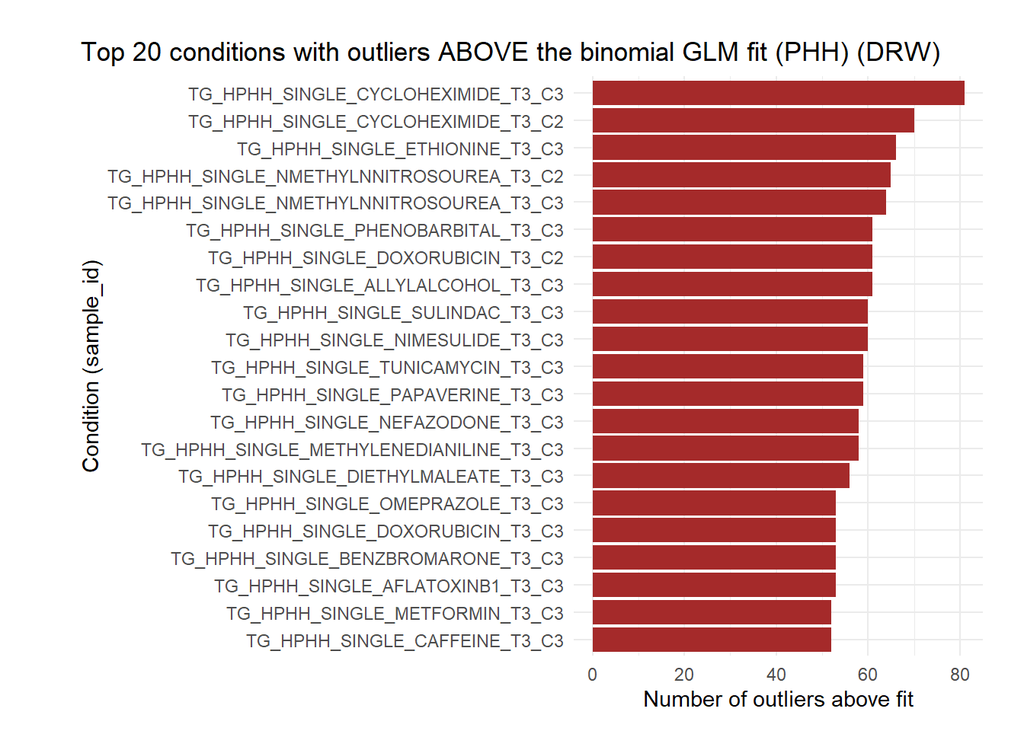

```r
GRR_glm_fit_df %>%
  filter(outlier_direction == "Above fit") %>%
  count(condition_id, sort = TRUE) %>%
  top_n(20, n) %>%
  ggplot(aes(x = reorder(condition_id, n), y = n)) +
  geom_col(fill = "brown") +
  coord_flip() +
  theme_minimal() +
  ggtitle("Top 20 conditions with outliers ABOVE the binomial GLM fit (PHH) (DRW)") +
  theme(
    plot.title.position = "plot",
    plot.title = element_text(hjust = 0),
    plot.margin = margin(20, 20, 10, 40)
  ) +
  labs(
    x = "Condition (sample_id)",
    y = "Number of outliers above fit"
  )
```

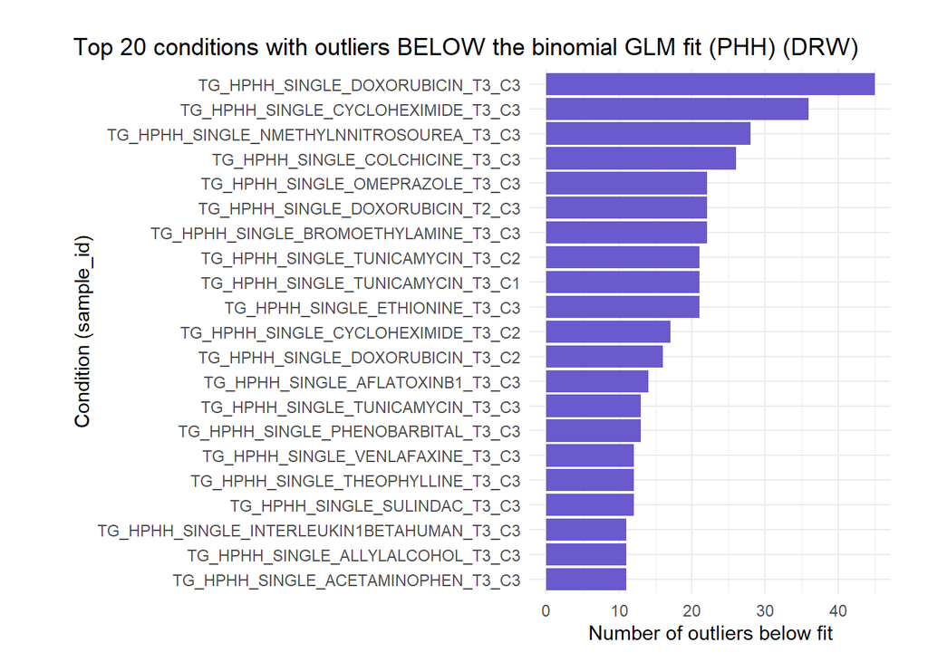

```r
GRR_glm_fit_df %>%
  filter(outlier_direction == "Below fit") %>%
  count(condition_id, sort = TRUE) %>%
  top_n(20, n) %>%
  ggplot(aes(x = reorder(condition_id, n), y = n)) +
  geom_col(fill = "slateblue") +
  coord_flip() +
  theme_minimal() +
  ggtitle("Top 20 conditions with outliers BELOW the binomial GLM fit (PHH) (DRW)") +
  theme(
    plot.title.position = "plot",
    plot.title = element_text(hjust = 0),
    plot.margin = margin(20, 20, 10, 40)
  ) +
  labs(
    x = "Condition (sample_id)",
    y = "Number of outliers below fit"
  )
```

# Conclusion

The DRW shows less outliers and a more ‘robust’ fit than the EG score on both the GRR and wGRR metric. It will be further assessed using other evaluations if the wDRW is better on other metrics as well.